# Risk Factor Analysis

## Outcome Variable

**Outcome Variable:** stunted

## Predictor Variables

**Intervention Variable:** tr

**Adjustment Set:**

unadjusted

## Stratifying Variables

The analysis was stratified on these variable(s):

- hhwealth_quart
- agecat
- studyid
- country

## Data Summary

| hhwealth_quart | agecat | studyid | country | tr | stunted | n_cell | n |
| --- | --- | --- | --- | --- | --- | --- | --- |
| Wealth Q4 | 24 months | ki1000110-WASH-Bangladesh | BANGLADESH | Control | 0 | 60 | 315 |
| Wealth Q4 | 24 months | ki1000110-WASH-Bangladesh | BANGLADESH | Control | 1 | 22 | 315 |
| Wealth Q4 | 24 months | ki1000110-WASH-Bangladesh | BANGLADESH | LNS | 0 | 50 | 315 |
| Wealth Q4 | 24 months | ki1000110-WASH-Bangladesh | BANGLADESH | LNS | 1 | 19 | 315 |
| Wealth Q4 | 24 months | ki1000110-WASH-Bangladesh | BANGLADESH | Other | 0 | 123 | 315 |
| Wealth Q4 | 24 months | ki1000110-WASH-Bangladesh | BANGLADESH | Other | 1 | 41 | 315 |
| Wealth Q2 | 24 months | ki1000110-WASH-Bangladesh | BANGLADESH | Control | 0 | 30 | 269 |
| Wealth Q2 | 24 months | ki1000110-WASH-Bangladesh | BANGLADESH | Control | 1 | 24 | 269 |
| Wealth Q2 | 24 months | ki1000110-WASH-Bangladesh | BANGLADESH | LNS | 0 | 44 | 269 |
| Wealth Q2 | 24 months | ki1000110-WASH-Bangladesh | BANGLADESH | LNS | 1 | 26 | 269 |
| Wealth Q2 | 24 months | ki1000110-WASH-Bangladesh | BANGLADESH | Other | 0 | 80 | 269 |
| Wealth Q2 | 24 months | ki1000110-WASH-Bangladesh | BANGLADESH | Other | 1 | 65 | 269 |
| Wealth Q1 | 24 months | ki1000110-WASH-Bangladesh | BANGLADESH | Control | 0 | 29 | 267 |
| Wealth Q1 | 24 months | ki1000110-WASH-Bangladesh | BANGLADESH | Control | 1 | 35 | 267 |
| Wealth Q1 | 24 months | ki1000110-WASH-Bangladesh | BANGLADESH | LNS | 0 | 37 | 267 |
| Wealth Q1 | 24 months | ki1000110-WASH-Bangladesh | BANGLADESH | LNS | 1 | 33 | 267 |
| Wealth Q1 | 24 months | ki1000110-WASH-Bangladesh | BANGLADESH | Other | 0 | 59 | 267 |
| Wealth Q1 | 24 months | ki1000110-WASH-Bangladesh | BANGLADESH | Other | 1 | 74 | 267 |
| Wealth Q3 | 24 months | ki1000110-WASH-Bangladesh | BANGLADESH | Control | 0 | 37 | 336 |
| Wealth Q3 | 24 months | ki1000110-WASH-Bangladesh | BANGLADESH | Control | 1 | 34 | 336 |
| Wealth Q3 | 24 months | ki1000110-WASH-Bangladesh | BANGLADESH | LNS | 0 | 60 | 336 |
| Wealth Q3 | 24 months | ki1000110-WASH-Bangladesh | BANGLADESH | LNS | 1 | 38 | 336 |
| Wealth Q3 | 24 months | ki1000110-WASH-Bangladesh | BANGLADESH | Other | 0 | 95 | 336 |
| Wealth Q3 | 24 months | ki1000110-WASH-Bangladesh | BANGLADESH | Other | 1 | 72 | 336 |
| Wealth Q3 | 6 months | ki1000110-WASH-Bangladesh | BANGLADESH | Control | 0 | 32 | 167 |
| Wealth Q3 | 6 months | ki1000110-WASH-Bangladesh | BANGLADESH | Control | 1 | 6 | 167 |
| Wealth Q3 | 6 months | ki1000110-WASH-Bangladesh | BANGLADESH | LNS | 0 | 41 | 167 |
| Wealth Q3 | 6 months | ki1000110-WASH-Bangladesh | BANGLADESH | LNS | 1 | 4 | 167 |
| Wealth Q3 | 6 months | ki1000110-WASH-Bangladesh | BANGLADESH | Other | 0 | 74 | 167 |
| Wealth Q3 | 6 months | ki1000110-WASH-Bangladesh | BANGLADESH | Other | 1 | 10 | 167 |

[output cut: 441 more lines]

The following strata were considered:

- hhwealth_quart: Wealth Q1, agecat: 24 months, studyid: iLiNS_DYADM_LNS, country: MALAWI
- hhwealth_quart: Wealth Q1, agecat: 24 months, studyid: ki1000110-WASH-Bangladesh, country: BANGLADESH
- hhwealth_quart: Wealth Q1, agecat: 24 months, studyid: ki1000111-WASH-Kenya, country: KENYA
- hhwealth_quart: Wealth Q1, agecat: 24 months, studyid: ki1066203-TanzaniaChild2, country: TANZANIA, UNITED REPUBLIC OF
- hhwealth_quart: Wealth Q1, agecat: 24 months, studyid: ki1135781-COHORTS, country: GUATEMALA
- hhwealth_quart: Wealth Q1, agecat: 24 months, studyid: ki1148112-iLiNS-DOSE, country: MALAWI
- hhwealth_quart: Wealth Q1, agecat: 24 months, studyid: ki1148112-iLiNS-DYAD-M, country: MALAWI
- hhwealth_quart: Wealth Q1, agecat: 24 months, studyid: ki1148112-LCNI-5, country: MALAWI
- hhwealth_quart: Wealth Q1, agecat: 24 months, studyid: kiGH5241-JiVitA-3, country: BANGLADESH
- hhwealth_quart: Wealth Q1, agecat: 24 months, studyid: kiGH5241-JiVitA-4, country: BANGLADESH
- hhwealth_quart: Wealth Q1, agecat: 6 months, studyid: iLiNS_DYADM_LNS, country: MALAWI
- hhwealth_quart: Wealth Q1, agecat: 6 months, studyid: ki1000110-WASH-Bangladesh, country: BANGLADESH
- hhwealth_quart: Wealth Q1, agecat: 6 months, studyid: ki1000111-WASH-Kenya, country: KENYA
- hhwealth_quart: Wealth Q1, agecat: 6 months, studyid: ki1000125-AgaKhanUniv, country: PAKISTAN
- hhwealth_quart: Wealth Q1, agecat: 6 months, studyid: ki1017093b-PROVIDE, country: BANGLADESH
- hhwealth_quart: Wealth Q1, agecat: 6 months, studyid: ki1066203-TanzaniaChild2, country: TANZANIA, UNITED REPUBLIC OF
- hhwealth_quart: Wealth Q1, agecat: 6 months, studyid: ki1135781-COHORTS, country: GUATEMALA
- hhwealth_quart: Wealth Q1, agecat: 6 months, studyid: ki1148112-iLiNS-DOSE, country: MALAWI
- hhwealth_quart: Wealth Q1, agecat: 6 months, studyid: ki1148112-iLiNS-DYAD-M, country: MALAWI
- hhwealth_quart: Wealth Q1, agecat: 6 months, studyid: ki1148112-LCNI-5, country: MALAWI
- hhwealth_quart: Wealth Q1, agecat: 6 months, studyid: kiGH5241-JiVitA-3, country: BANGLADESH
- hhwealth_quart: Wealth Q1, agecat: 6 months, studyid: kiGH5241-JiVitA-4, country: BANGLADESH
- hhwealth_quart: Wealth Q1, agecat: Birth, studyid: iLiNS_DYADM_LNS, country: MALAWI
- hhwealth_quart: Wealth Q1, agecat: Birth, studyid: ki1000125-AgaKhanUniv, country: PAKISTAN
- hhwealth_quart: Wealth Q1, agecat: Birth, studyid: ki1135781-COHORTS, country: GUATEMALA
- hhwealth_quart: Wealth Q1, agecat: Birth, studyid: ki1148112-iLiNS-DYAD-M, country: MALAWI
- hhwealth_quart: Wealth Q1, agecat: Birth, studyid: kiGH5241-JiVitA-3, country: BANGLADESH
- hhwealth_quart: Wealth Q1, agecat: Birth, studyid: kiGH5241-JiVitA-4, country: BANGLADESH
- hhwealth_quart: Wealth Q2, agecat: 24 months, studyid: iLiNS_DYADM_LNS, country: MALAWI
- hhwealth_quart: Wealth Q2, agecat: 24 months, studyid: ki1000110-WASH-Bangladesh, country: BANGLADESH
- hhwealth_quart: Wealth Q2, agecat: 24 months, studyid: ki1000111-WASH-Kenya, country: KENYA
- hhwealth_quart: Wealth Q2, agecat: 24 months, studyid: ki1066203-TanzaniaChild2, country: TANZANIA, UNITED REPUBLIC OF
- hhwealth_quart: Wealth Q2, agecat: 24 months, studyid: ki1135781-COHORTS, country: GUATEMALA
- hhwealth_quart: Wealth Q2, agecat: 24 months, studyid: ki1148112-iLiNS-DOSE, country: MALAWI
- hhwealth_quart: Wealth Q2, agecat: 24 months, studyid: ki1148112-iLiNS-DYAD-M, country: MALAWI
- hhwealth_quart: Wealth Q2, agecat: 24 months, studyid: ki1148112-LCNI-5, country: MALAWI
- hhwealth_quart: Wealth Q2, agecat: 24 months, studyid: kiGH5241-JiVitA-3, country: BANGLADESH
- hhwealth_quart: Wealth Q2, agecat: 24 months, studyid: kiGH5241-JiVitA-4, country: BANGLADESH
- hhwealth_quart: Wealth Q2, agecat: 6 months, studyid: iLiNS_DYADM_LNS, country: MALAWI
- hhwealth_quart: Wealth Q2, agecat: 6 months, studyid: ki1000110-WASH-Bangladesh, country: BANGLADESH
- hhwealth_quart: Wealth Q2, agecat: 6 months, studyid: ki1000111-WASH-Kenya, country: KENYA
- hhwealth_quart: Wealth Q2, agecat: 6 months, studyid: ki1000125-AgaKhanUniv, country: PAKISTAN
- hhwealth_quart: Wealth Q2, agecat: 6 months, studyid: ki1017093b-PROVIDE, country: BANGLADESH
- hhwealth_quart: Wealth Q2, agecat: 6 months, studyid: ki1066203-TanzaniaChild2, country: TANZANIA, UNITED REPUBLIC OF
- hhwealth_quart: Wealth Q2, agecat: 6 months, studyid: ki1135781-COHORTS, country: GUATEMALA
- hhwealth_quart: Wealth Q2, agecat: 6 months, studyid: ki1148112-iLiNS-DOSE, country: MALAWI
- hhwealth_quart: Wealth Q2, agecat: 6 months, studyid: ki1148112-iLiNS-DYAD-M, country: MALAWI
- hhwealth_quart: Wealth Q2, agecat: 6 months, studyid: ki1148112-LCNI-5, country: MALAWI
- hhwealth_quart: Wealth Q2, agecat: 6 months, studyid: kiGH5241-JiVitA-3, country: BANGLADESH
- hhwealth_quart: Wealth Q2, agecat: 6 months, studyid: kiGH5241-JiVitA-4, country: BANGLADESH
- hhwealth_quart: Wealth Q2, agecat: Birth, studyid: ki1000125-AgaKhanUniv, country: PAKISTAN
- hhwealth_quart: Wealth Q2, agecat: Birth, studyid: ki1135781-COHORTS, country: GUATEMALA
- hhwealth_quart: Wealth Q2, agecat: Birth, studyid: kiGH5241-JiVitA-3, country: BANGLADESH
- hhwealth_quart: Wealth Q2, agecat: Birth, studyid: kiGH5241-JiVitA-4, country: BANGLADESH
- hhwealth_quart: Wealth Q3, agecat: 24 months, studyid: iLiNS_DYADM_LNS, country: MALAWI
- hhwealth_quart: Wealth Q3, agecat: 24 months, studyid: ki1000110-WASH-Bangladesh, country: BANGLADESH
- hhwealth_quart: Wealth Q3, agecat: 24 months, studyid: ki1000111-WASH-Kenya, country: KENYA
- hhwealth_quart: Wealth Q3, agecat: 24 months, studyid: ki1000125-AgaKhanUniv, country: PAKISTAN
- hhwealth_quart: Wealth Q3, agecat: 24 months, studyid: ki1017093b-PROVIDE, country: BANGLADESH
- hhwealth_quart: Wealth Q3, agecat: 24 months, studyid: ki1135781-COHORTS, country: GUATEMALA
- hhwealth_quart: Wealth Q3, agecat: 24 months, studyid: ki1148112-iLiNS-DOSE, country: MALAWI
- hhwealth_quart: Wealth Q3, agecat: 24 months, studyid: ki1148112-iLiNS-DYAD-M, country: MALAWI
- hhwealth_quart: Wealth Q3, agecat: 24 months, studyid: ki1148112-LCNI-5, country: MALAWI
- hhwealth_quart: Wealth Q3, agecat: 24 months, studyid: kiGH5241-JiVitA-3, country: BANGLADESH
- hhwealth_quart: Wealth Q3, agecat: 24 months, studyid: kiGH5241-JiVitA-4, country: BANGLADESH
- hhwealth_quart: Wealth Q3, agecat: 6 months, studyid: iLiNS_DYADM_LNS, country: MALAWI
- hhwealth_quart: Wealth Q3, agecat: 6 months, studyid: ki1000110-WASH-Bangladesh, country: BANGLADESH
- hhwealth_quart: Wealth Q3, agecat: 6 months, studyid: ki1000111-WASH-Kenya, country: KENYA
- hhwealth_quart: Wealth Q3, agecat: 6 months, studyid: ki1000125-AgaKhanUniv, country: PAKISTAN
- hhwealth_quart: Wealth Q3, agecat: 6 months, studyid: ki1017093b-PROVIDE, country: BANGLADESH
- hhwealth_quart: Wealth Q3, agecat: 6 months, studyid: ki1066203-TanzaniaChild2, country: TANZANIA, UNITED REPUBLIC OF
- hhwealth_quart: Wealth Q3, agecat: 6 months, studyid: ki1135781-COHORTS, country: GUATEMALA
- hhwealth_quart: Wealth Q3, agecat: 6 months, studyid: ki1148112-iLiNS-DOSE, country: MALAWI
- hhwealth_quart: Wealth Q3, agecat: 6 months, studyid: ki1148112-iLiNS-DYAD-M, country: MALAWI
- hhwealth_quart: Wealth Q3, agecat: 6 months, studyid: ki1148112-LCNI-5, country: MALAWI
- hhwealth_quart: Wealth Q3, agecat: 6 months, studyid: kiGH5241-JiVitA-3, country: BANGLADESH
- hhwealth_quart: Wealth Q3, agecat: 6 months, studyid: kiGH5241-JiVitA-4, country: BANGLADESH
- hhwealth_quart: Wealth Q3, agecat: Birth, studyid: ki1135781-COHORTS, country: GUATEMALA
- hhwealth_quart: Wealth Q3, agecat: Birth, studyid: kiGH5241-JiVitA-3, country: BANGLADESH
- hhwealth_quart: Wealth Q3, agecat: Birth, studyid: kiGH5241-JiVitA-4, country: BANGLADESH
- hhwealth_quart: Wealth Q4, agecat: 24 months, studyid: iLiNS_DYADM_LNS, country: MALAWI
- hhwealth_quart: Wealth Q4, agecat: 24 months, studyid: ki1000110-WASH-Bangladesh, country: BANGLADESH
- hhwealth_quart: Wealth Q4, agecat: 24 months, studyid: ki1000111-WASH-Kenya, country: KENYA
- hhwealth_quart: Wealth Q4, agecat: 24 months, studyid: ki1017093b-PROVIDE, country: BANGLADESH
- hhwealth_quart: Wealth Q4, agecat: 24 months, studyid: ki1066203-TanzaniaChild2, country: TANZANIA, UNITED REPUBLIC OF
- hhwealth_quart: Wealth Q4, agecat: 24 months, studyid: ki1135781-COHORTS, country: GUATEMALA
- hhwealth_quart: Wealth Q4, agecat: 24 months, studyid: ki1148112-iLiNS-DOSE, country: MALAWI
- hhwealth_quart: Wealth Q4, agecat: 24 months, studyid: ki1148112-iLiNS-DYAD-M, country: MALAWI
- hhwealth_quart: Wealth Q4, agecat: 24 months, studyid: ki1148112-LCNI-5, country: MALAWI
- hhwealth_quart: Wealth Q4, agecat: 24 months, studyid: kiGH5241-JiVitA-3, country: BANGLADESH
- hhwealth_quart: Wealth Q4, agecat: 24 months, studyid: kiGH5241-JiVitA-4, country: BANGLADESH
- hhwealth_quart: Wealth Q4, agecat: 6 months, studyid: iLiNS_DYADM_LNS, country: MALAWI
- hhwealth_quart: Wealth Q4, agecat: 6 months, studyid: ki1000110-WASH-Bangladesh, country: BANGLADESH
- hhwealth_quart: Wealth Q4, agecat: 6 months, studyid: ki1000111-WASH-Kenya, country: KENYA
- hhwealth_quart: Wealth Q4, agecat: 6 months, studyid: ki1000125-AgaKhanUniv, country: PAKISTAN
- hhwealth_quart: Wealth Q4, agecat: 6 months, studyid: ki1017093b-PROVIDE, country: BANGLADESH
- hhwealth_quart: Wealth Q4, agecat: 6 months, studyid: ki1066203-TanzaniaChild2, country: TANZANIA, UNITED REPUBLIC OF
- hhwealth_quart: Wealth Q4, agecat: 6 months, studyid: ki1135781-COHORTS, country: GUATEMALA
- hhwealth_quart: Wealth Q4, agecat: 6 months, studyid: ki1148112-iLiNS-DOSE, country: MALAWI
- hhwealth_quart: Wealth Q4, agecat: 6 months, studyid: ki1148112-iLiNS-DYAD-M, country: MALAWI
- hhwealth_quart: Wealth Q4, agecat: 6 months, studyid: ki1148112-LCNI-5, country: MALAWI
- hhwealth_quart: Wealth Q4, agecat: 6 months, studyid: kiGH5241-JiVitA-3, country: BANGLADESH
- hhwealth_quart: Wealth Q4, agecat: 6 months, studyid: kiGH5241-JiVitA-4, country: BANGLADESH
- hhwealth_quart: Wealth Q4, agecat: Birth, studyid: ki1135781-COHORTS, country: GUATEMALA
- hhwealth_quart: Wealth Q4, agecat: Birth, studyid: kiGH5241-JiVitA-3, country: BANGLADESH
- hhwealth_quart: Wealth Q4, agecat: Birth, studyid: kiGH5241-JiVitA-4, country: BANGLADESH

### Dropped Strata

Some strata were dropped due to rare outcomes:

- hhwealth_quart: Wealth Q3, agecat: 6 months, studyid: ki1000110-WASH-Bangladesh, country: BANGLADESH
- hhwealth_quart: Wealth Q4, agecat: 6 months, studyid: ki1000110-WASH-Bangladesh, country: BANGLADESH
- hhwealth_quart: Wealth Q1, agecat: 6 months, studyid: ki1000111-WASH-Kenya, country: KENYA
- hhwealth_quart: Wealth Q2, agecat: 6 months, studyid: ki1000111-WASH-Kenya, country: KENYA
- hhwealth_quart: Wealth Q3, agecat: 6 months, studyid: ki1000111-WASH-Kenya, country: KENYA
- hhwealth_quart: Wealth Q4, agecat: 6 months, studyid: ki1000111-WASH-Kenya, country: KENYA
- hhwealth_quart: Wealth Q2, agecat: 6 months, studyid: ki1000125-AgaKhanUniv, country: PAKISTAN
- hhwealth_quart: Wealth Q3, agecat: 24 months, studyid: ki1000125-AgaKhanUniv, country: PAKISTAN
- hhwealth_quart: Wealth Q1, agecat: Birth, studyid: ki1000125-AgaKhanUniv, country: PAKISTAN
- hhwealth_quart: Wealth Q2, agecat: Birth, studyid: ki1000125-AgaKhanUniv, country: PAKISTAN
- hhwealth_quart: Wealth Q4, agecat: 6 months, studyid: ki1017093b-PROVIDE, country: BANGLADESH
- hhwealth_quart: Wealth Q1, agecat: 6 months, studyid: ki1017093b-PROVIDE, country: BANGLADESH
- hhwealth_quart: Wealth Q3, agecat: 6 months, studyid: ki1017093b-PROVIDE, country: BANGLADESH
- hhwealth_quart: Wealth Q2, agecat: 6 months, studyid: ki1017093b-PROVIDE, country: BANGLADESH
- hhwealth_quart: Wealth Q3, agecat: 24 months, studyid: ki1017093b-PROVIDE, country: BANGLADESH
- hhwealth_quart: Wealth Q4, agecat: 24 months, studyid: ki1017093b-PROVIDE, country: BANGLADESH
- hhwealth_quart: Wealth Q2, agecat: 6 months, studyid: ki1066203-TanzaniaChild2, country: TANZANIA, UNITED REPUBLIC OF
- hhwealth_quart: Wealth Q1, agecat: 24 months, studyid: ki1066203-TanzaniaChild2, country: TANZANIA, UNITED REPUBLIC OF
- hhwealth_quart: Wealth Q4, agecat: 24 months, studyid: ki1066203-TanzaniaChild2, country: TANZANIA, UNITED REPUBLIC OF
- hhwealth_quart: Wealth Q2, agecat: 24 months, studyid: ki1066203-TanzaniaChild2, country: TANZANIA, UNITED REPUBLIC OF
- hhwealth_quart: Wealth Q4, agecat: Birth, studyid: ki1135781-COHORTS, country: GUATEMALA
- hhwealth_quart: Wealth Q3, agecat: 24 months, studyid: ki1135781-COHORTS, country: GUATEMALA
- hhwealth_quart: Wealth Q3, agecat: Birth, studyid: ki1135781-COHORTS, country: GUATEMALA
- hhwealth_quart: Wealth Q1, agecat: Birth, studyid: ki1135781-COHORTS, country: GUATEMALA
- hhwealth_quart: Wealth Q1, agecat: 24 months, studyid: ki1135781-COHORTS, country: GUATEMALA
- hhwealth_quart: Wealth Q1, agecat: Birth, studyid: ki1148112-iLiNS-DYAD-M, country: MALAWI
- hhwealth_quart: Wealth Q1, agecat: 24 months, studyid: ki1148112-iLiNS-DYAD-M, country: MALAWI
- hhwealth_quart: Wealth Q2, agecat: 24 months, studyid: ki1148112-iLiNS-DYAD-M, country: MALAWI
- hhwealth_quart: Wealth Q3, agecat: 24 months, studyid: ki1148112-iLiNS-DYAD-M, country: MALAWI
- hhwealth_quart: Wealth Q4, agecat: 24 months, studyid: ki1148112-iLiNS-DYAD-M, country: MALAWI
- hhwealth_quart: Wealth Q1, agecat: 24 months, studyid: kiGH5241-JiVitA-3, country: BANGLADESH
- hhwealth_quart: Wealth Q2, agecat: 24 months, studyid: kiGH5241-JiVitA-3, country: BANGLADESH
- hhwealth_quart: Wealth Q1, agecat: Birth, studyid: iLiNS_DYADM_LNS, country: MALAWI
- hhwealth_quart: Wealth Q1, agecat: 24 months, studyid: iLiNS_DYADM_LNS, country: MALAWI
- hhwealth_quart: Wealth Q2, agecat: 24 months, studyid: iLiNS_DYADM_LNS, country: MALAWI
- hhwealth_quart: Wealth Q3, agecat: 24 months, studyid: iLiNS_DYADM_LNS, country: MALAWI
- hhwealth_quart: Wealth Q4, agecat: 24 months, studyid: iLiNS_DYADM_LNS, country: MALAWI

## Methods Detail

We’re interested in the causal parameters $E[Y_a]$ for all values of $a \in \mathcal{A}$. These parameters represent the mean outcome if, possibly contrary to fact, we intervened to set all units to have $A=a$. Under the randomization and positivity assumptions, these are identified by the statistical parameters $\psi_a=E_W[E_{Y|A,W}(Y|A=a,W)]$. In addition, we’re interested in the mean of $Y$, $E[Y]$ under no intervention (the observed mean). We will estimate these parameters by using SuperLearner to fit the relevant likelihood factors – $E_{Y|A,W}(Y|A=a,W)$ and $p(A=a|W)$, and then updating our likelihood fit using a joint TMLE.

For unadjusted analyses ($W=\{\}$), initial likelihoods were estimated using Lrnr_glm to estimate the simple $E(Y|A)$ and Lrnr_mean to estimate $p(A)$. For adjusted analyses, a small library containing Lrnr_glmnet, Lrnr_xgboost, and Lrnr_mean was used.

Having estimated these parameters, we will then use the delta method to estimate relative risks and attributable risks relative to a prespecified baseline level of $A$.

# Results Detail

## Results Plots

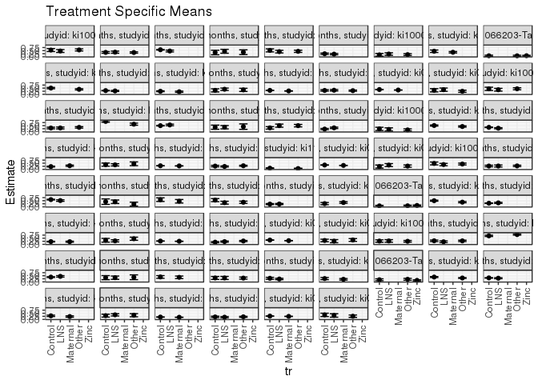

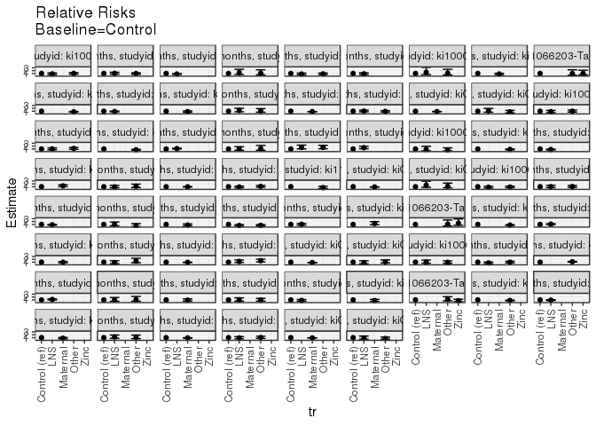

[figure not shown]

[figure not shown]

## Results Table

### Parameter: TSM

| hhwealth_quart | agecat | studyid | country | intervention_level | baseline_level | estimate | ci_lower | ci_upper |
| --- | --- | --- | --- | --- | --- | --- | --- | --- |
| Wealth Q4 | Birth | kiGH5241-JiVitA-3 | BANGLADESH | Control | NA | 0.2673031 | 0.2565114 | 0.2780948 |
| Wealth Q4 | Birth | kiGH5241-JiVitA-3 | BANGLADESH | Maternal | NA | 0.2441634 | 0.2337062 | 0.2546207 |
| Wealth Q4 | Birth | kiGH5241-JiVitA-4 | BANGLADESH | Control | NA | 0.3673469 | 0.2314275 | 0.5032664 |
| Wealth Q4 | Birth | kiGH5241-JiVitA-4 | BANGLADESH | LNS | NA | 0.3207547 | 0.1788510 | 0.4626584 |
| Wealth Q4 | Birth | kiGH5241-JiVitA-4 | BANGLADESH | Other | NA | 0.2592593 | 0.1621314 | 0.3563872 |
| Wealth Q4 | 6 months | iLiNS_DYADM_LNS | MALAWI | Control | NA | 0.2909091 | 0.2127805 | 0.3690377 |
| Wealth Q4 | 6 months | iLiNS_DYADM_LNS | MALAWI | LNS | NA | 0.2333333 | 0.1795991 | 0.2870676 |
| Wealth Q4 | 6 months | ki1000125-AgaKhanUniv | PAKISTAN | Control | NA | 0.2702703 | 0.1827540 | 0.3577865 |
| Wealth Q4 | 6 months | ki1000125-AgaKhanUniv | PAKISTAN | Maternal | NA | 0.2083333 | 0.1438773 | 0.2727894 |
| Wealth Q4 | 6 months | ki1066203-TanzaniaChild2 | TANZANIA, UNITED REPUBLIC OF | Control | NA | 0.1734694 | 0.0984118 | 0.2485270 |
| Wealth Q4 | 6 months | ki1066203-TanzaniaChild2 | TANZANIA, UNITED REPUBLIC OF | Other | NA | 0.2090909 | 0.1330055 | 0.2851763 |
| Wealth Q4 | 6 months | ki1066203-TanzaniaChild2 | TANZANIA, UNITED REPUBLIC OF | Zinc | NA | 0.1232227 | 0.0788194 | 0.1676261 |
| Wealth Q4 | 6 months | ki1135781-COHORTS | GUATEMALA | Control | NA | 0.3939394 | 0.3562621 | 0.4316167 |
| Wealth Q4 | 6 months | ki1135781-COHORTS | GUATEMALA | Other | NA | 0.3148148 | 0.2793290 | 0.3503006 |
| Wealth Q4 | 6 months | ki1148112-iLiNS-DOSE | MALAWI | Control | NA | 0.3239437 | 0.3018302 | 0.3460571 |
| Wealth Q4 | 6 months | ki1148112-iLiNS-DOSE | MALAWI | LNS | NA | 0.2974910 | 0.2546691 | 0.3403130 |
| Wealth Q4 | 6 months | ki1148112-iLiNS-DYAD-M | MALAWI | Control | NA | 0.2909091 | 0.2332513 | 0.3485668 |
| Wealth Q4 | 6 months | ki1148112-iLiNS-DYAD-M | MALAWI | Maternal | NA | 0.2333333 | 0.1772526 | 0.2894141 |
| Wealth Q4 | 6 months | ki1148112-LCNI-5 | MALAWI | Control | NA | 0.3050847 | 0.1873238 | 0.4228457 |
| Wealth Q4 | 6 months | ki1148112-LCNI-5 | MALAWI | LNS | NA | 0.3714286 | 0.2787944 | 0.4640628 |
| Wealth Q4 | 6 months | ki1148112-LCNI-5 | MALAWI | Other | NA | 0.3396226 | 0.2118295 | 0.4674158 |
| Wealth Q4 | 6 months | kiGH5241-JiVitA-3 | BANGLADESH | Control | NA | 0.1908784 | 0.1808060 | 0.2009508 |
| Wealth Q4 | 6 months | kiGH5241-JiVitA-3 | BANGLADESH | Maternal | NA | 0.1734349 | 0.1638117 | 0.1830580 |
| Wealth Q4 | 6 months | kiGH5241-JiVitA-4 | BANGLADESH | Control | NA | 0.2000000 | 0.1419993 | 0.2580007 |
| Wealth Q4 | 6 months | kiGH5241-JiVitA-4 | BANGLADESH | LNS | NA | 0.1798107 | 0.1267735 | 0.2328480 |
| Wealth Q4 | 6 months | kiGH5241-JiVitA-4 | BANGLADESH | Other | NA | 0.2094340 | 0.1689920 | 0.2498759 |
| Wealth Q4 | 24 months | ki1000110-WASH-Bangladesh | BANGLADESH | Control | NA | 0.2682927 | 0.1722411 | 0.3643443 |
| Wealth Q4 | 24 months | ki1000110-WASH-Bangladesh | BANGLADESH | LNS | NA | 0.2753623 | 0.1697957 | 0.3809290 |
| Wealth Q4 | 24 months | ki1000110-WASH-Bangladesh | BANGLADESH | Other | NA | 0.2500000 | 0.1836231 | 0.3163769 |
| Wealth Q4 | 24 months | ki1000111-WASH-Kenya | KENYA | Control | NA | 0.2900000 | 0.2270568 | 0.3529432 |

[output cut: 141 more lines]

### Parameter: E(Y)

| hhwealth_quart | agecat | studyid | country | intervention_level | baseline_level | estimate | ci_lower | ci_upper |
| --- | --- | --- | --- | --- | --- | --- | --- | --- |
| Wealth Q4 | Birth | kiGH5241-JiVitA-3 | BANGLADESH | NA | NA | 0.2558420 | 0.2407916 | 0.2708924 |
| Wealth Q4 | Birth | kiGH5241-JiVitA-4 | BANGLADESH | NA | NA | 0.3060109 | 0.2357250 | 0.3762969 |
| Wealth Q4 | 6 months | iLiNS_DYADM_LNS | MALAWI | NA | NA | 0.2705882 | 0.1755826 | 0.3655939 |
| Wealth Q4 | 6 months | ki1000125-AgaKhanUniv | PAKISTAN | NA | NA | 0.2459016 | 0.1369416 | 0.3548617 |
| Wealth Q4 | 6 months | ki1066203-TanzaniaChild2 | TANZANIA, UNITED REPUBLIC OF | NA | NA | 0.1575179 | 0.1225954 | 0.1924404 |
| Wealth Q4 | 6 months | ki1135781-COHORTS | GUATEMALA | NA | NA | 0.3547401 | 0.3028049 | 0.4066753 |
| Wealth Q4 | 6 months | ki1148112-iLiNS-DOSE | MALAWI | NA | NA | 0.3028571 | 0.2546496 | 0.3510647 |
| Wealth Q4 | 6 months | ki1148112-iLiNS-DYAD-M | MALAWI | NA | NA | 0.2608696 | 0.1802635 | 0.3414757 |
| Wealth Q4 | 6 months | ki1148112-LCNI-5 | MALAWI | NA | NA | 0.3456221 | 0.2822007 | 0.4090436 |
| Wealth Q4 | 6 months | kiGH5241-JiVitA-3 | BANGLADESH | NA | NA | 0.1821640 | 0.1681996 | 0.1961283 |
| Wealth Q4 | 6 months | kiGH5241-JiVitA-4 | BANGLADESH | NA | NA | 0.1987633 | 0.1706207 | 0.2269058 |
| Wealth Q4 | 24 months | ki1000110-WASH-Bangladesh | BANGLADESH | NA | NA | 0.2603175 | 0.2117822 | 0.3088527 |
| Wealth Q4 | 24 months | ki1000111-WASH-Kenya | KENYA | NA | NA | 0.2691622 | 0.2324279 | 0.3058965 |
| Wealth Q4 | 24 months | ki1135781-COHORTS | GUATEMALA | NA | NA | 0.7446809 | 0.6724520 | 0.8169097 |
| Wealth Q4 | 24 months | ki1148112-iLiNS-DOSE | MALAWI | NA | NA | 0.4371859 | 0.3680934 | 0.5062785 |
| Wealth Q4 | 24 months | ki1148112-LCNI-5 | MALAWI | NA | NA | 0.3495146 | 0.2569810 | 0.4420482 |
| Wealth Q4 | 24 months | kiGH5241-JiVitA-3 | BANGLADESH | NA | NA | 0.3846154 | 0.2308090 | 0.5384218 |
| Wealth Q4 | 24 months | kiGH5241-JiVitA-4 | BANGLADESH | NA | NA | 0.3132075 | 0.2523471 | 0.3740680 |
| Wealth Q1 | Birth | kiGH5241-JiVitA-3 | BANGLADESH | NA | NA | 0.3671665 | 0.3506706 | 0.3836623 |
| Wealth Q1 | Birth | kiGH5241-JiVitA-4 | BANGLADESH | NA | NA | 0.3014354 | 0.2364879 | 0.3663829 |
| Wealth Q1 | 6 months | iLiNS_DYADM_LNS | MALAWI | NA | NA | 0.2314815 | 0.1515641 | 0.3113989 |
| Wealth Q1 | 6 months | ki1000110-WASH-Bangladesh | BANGLADESH | NA | NA | 0.1877934 | 0.1352215 | 0.2403653 |
| Wealth Q1 | 6 months | ki1000125-AgaKhanUniv | PAKISTAN | NA | NA | 0.4285714 | 0.3118055 | 0.5453374 |
| Wealth Q1 | 6 months | ki1066203-TanzaniaChild2 | TANZANIA, UNITED REPUBLIC OF | NA | NA | 0.0830040 | 0.0589417 | 0.1070662 |
| Wealth Q1 | 6 months | ki1135781-COHORTS | GUATEMALA | NA | NA | 0.4583333 | 0.3827638 | 0.5339028 |
| Wealth Q1 | 6 months | ki1148112-iLiNS-DOSE | MALAWI | NA | NA | 0.2771429 | 0.2301844 | 0.3241013 |
| Wealth Q1 | 6 months | ki1148112-iLiNS-DYAD-M | MALAWI | NA | NA | 0.2203390 | 0.1591053 | 0.2815727 |
| Wealth Q1 | 6 months | ki1148112-LCNI-5 | MALAWI | NA | NA | 0.3743842 | 0.3076444 | 0.4411241 |
| Wealth Q1 | 6 months | kiGH5241-JiVitA-3 | BANGLADESH | NA | NA | 0.2945799 | 0.2761186 | 0.3130413 |
| Wealth Q1 | 6 months | kiGH5241-JiVitA-4 | BANGLADESH | NA | NA | 0.3102007 | 0.2784381 | 0.3419632 |
| Wealth Q1 | 24 months | ki1000110-WASH-Bangladesh | BANGLADESH | NA | NA | 0.5318352 | 0.4718706 | 0.5917998 |
| Wealth Q1 | 24 months | ki1000111-WASH-Kenya | KENYA | NA | NA | 0.3564014 | 0.3173229 | 0.3954798 |
| Wealth Q1 | 24 months | ki1148112-iLiNS-DOSE | MALAWI | NA | NA | 0.4832215 | 0.4027128 | 0.5637301 |
| Wealth Q1 | 24 months | ki1148112-LCNI-5 | MALAWI | NA | NA | 0.3977273 | 0.2948836 | 0.5005710 |
| Wealth Q1 | 24 months | kiGH5241-JiVitA-4 | BANGLADESH | NA | NA | 0.4548387 | 0.3946888 | 0.5149886 |
| Wealth Q2 | Birth | ki1135781-COHORTS | GUATEMALA | NA | NA | 0.0745342 | 0.0338387 | 0.1152296 |
| Wealth Q2 | Birth | kiGH5241-JiVitA-3 | BANGLADESH | NA | NA | 0.3322110 | 0.3163556 | 0.3480664 |
| Wealth Q2 | Birth | kiGH5241-JiVitA-4 | BANGLADESH | NA | NA | 0.2785388 | 0.2144783 | 0.3425993 |
| Wealth Q2 | 6 months | iLiNS_DYADM_LNS | MALAWI | NA | NA | 0.2727273 | 0.1964623 | 0.3489923 |
| Wealth Q2 | 6 months | ki1000110-WASH-Bangladesh | BANGLADESH | NA | NA | 0.1870968 | 0.1255025 | 0.2486910 |
| Wealth Q2 | 6 months | ki1135781-COHORTS | GUATEMALA | NA | NA | 0.4663212 | 0.3957578 | 0.5368847 |
| Wealth Q2 | 6 months | ki1148112-iLiNS-DOSE | MALAWI | NA | NA | 0.3028571 | 0.2546496 | 0.3510647 |
| Wealth Q2 | 6 months | ki1148112-iLiNS-DYAD-M | MALAWI | NA | NA | 0.2673797 | 0.2037741 | 0.3309853 |
| Wealth Q2 | 6 months | ki1148112-LCNI-5 | MALAWI | NA | NA | 0.3869347 | 0.3190944 | 0.4547750 |
| Wealth Q2 | 6 months | kiGH5241-JiVitA-3 | BANGLADESH | NA | NA | 0.2835749 | 0.2669016 | 0.3002481 |
| Wealth Q2 | 6 months | kiGH5241-JiVitA-4 | BANGLADESH | NA | NA | 0.2684954 | 0.2400699 | 0.2969210 |
| Wealth Q2 | 24 months | ki1000110-WASH-Bangladesh | BANGLADESH | NA | NA | 0.4275093 | 0.3682798 | 0.4867387 |
| Wealth Q2 | 24 months | ki1000111-WASH-Kenya | KENYA | NA | NA | 0.3315972 | 0.2931169 | 0.3700775 |
| Wealth Q2 | 24 months | ki1135781-COHORTS | GUATEMALA | NA | NA | 0.7377049 | 0.6264014 | 0.8490084 |
| Wealth Q2 | 24 months | ki1148112-iLiNS-DOSE | MALAWI | NA | NA | 0.5497382 | 0.4789955 | 0.6204809 |
| Wealth Q2 | 24 months | ki1148112-LCNI-5 | MALAWI | NA | NA | 0.3838384 | 0.2875538 | 0.4801229 |
| Wealth Q2 | 24 months | kiGH5241-JiVitA-4 | BANGLADESH | NA | NA | 0.4457364 | 0.3816321 | 0.5098408 |
| Wealth Q3 | Birth | kiGH5241-JiVitA-3 | BANGLADESH | NA | NA | 0.3242084 | 0.3091807 | 0.3392360 |
| Wealth Q3 | Birth | kiGH5241-JiVitA-4 | BANGLADESH | NA | NA | 0.3175355 | 0.2509916 | 0.3840795 |
| Wealth Q3 | 6 months | iLiNS_DYADM_LNS | MALAWI | NA | NA | 0.2269939 | 0.1624895 | 0.2914982 |
| Wealth Q3 | 6 months | ki1000125-AgaKhanUniv | PAKISTAN | NA | NA | 0.2903226 | 0.1764146 | 0.4042305 |
| Wealth Q3 | 6 months | ki1066203-TanzaniaChild2 | TANZANIA, UNITED REPUBLIC OF | NA | NA | 0.0949074 | 0.0672376 | 0.1225772 |
| Wealth Q3 | 6 months | ki1135781-COHORTS | GUATEMALA | NA | NA | 0.4326923 | 0.3651988 | 0.5001858 |
| Wealth Q3 | 6 months | ki1148112-iLiNS-DOSE | MALAWI | NA | NA | 0.3180516 | 0.2691207 | 0.3669825 |
| Wealth Q3 | 6 months | ki1148112-iLiNS-DYAD-M | MALAWI | NA | NA | 0.2191235 | 0.1678476 | 0.2703995 |
| Wealth Q3 | 6 months | ki1148112-LCNI-5 | MALAWI | NA | NA | 0.3451777 | 0.2786192 | 0.4117361 |
| Wealth Q3 | 6 months | kiGH5241-JiVitA-3 | BANGLADESH | NA | NA | 0.2596567 | 0.2447459 | 0.2745674 |
| Wealth Q3 | 6 months | kiGH5241-JiVitA-4 | BANGLADESH | NA | NA | 0.2331483 | 0.2062975 | 0.2599991 |
| Wealth Q3 | 24 months | ki1000110-WASH-Bangladesh | BANGLADESH | NA | NA | 0.4285714 | 0.3755785 | 0.4815644 |
| Wealth Q3 | 24 months | ki1000111-WASH-Kenya | KENYA | NA | NA | 0.2737226 | 0.2363580 | 0.3110873 |
| Wealth Q3 | 24 months | ki1148112-iLiNS-DOSE | MALAWI | NA | NA | 0.5243243 | 0.4521646 | 0.5964840 |
| Wealth Q3 | 24 months | ki1148112-LCNI-5 | MALAWI | NA | NA | 0.3586957 | 0.2601534 | 0.4572379 |
| Wealth Q3 | 24 months | kiGH5241-JiVitA-3 | BANGLADESH | NA | NA | 0.5217391 | 0.3130038 | 0.7304744 |
| Wealth Q3 | 24 months | kiGH5241-JiVitA-4 | BANGLADESH | NA | NA | 0.4061303 | 0.3435552 | 0.4687053 |

### Parameter: RR

| hhwealth_quart | agecat | studyid | country | intervention_level | baseline_level | estimate | ci_lower | ci_upper |
| --- | --- | --- | --- | --- | --- | --- | --- | --- |
| Wealth Q4 | Birth | kiGH5241-JiVitA-3 | BANGLADESH | Control | Control | 1.0000000 | 1.0000000 | 1.0000000 |
| Wealth Q4 | Birth | kiGH5241-JiVitA-3 | BANGLADESH | Maternal | Control | 0.9134328 | 0.8612205 | 0.9688105 |
| Wealth Q4 | Birth | kiGH5241-JiVitA-4 | BANGLADESH | Control | Control | 1.0000000 | 1.0000000 | 1.0000000 |
| Wealth Q4 | Birth | kiGH5241-JiVitA-4 | BANGLADESH | LNS | Control | 0.8731656 | 0.4904248 | 1.5546076 |
| Wealth Q4 | Birth | kiGH5241-JiVitA-4 | BANGLADESH | Other | Control | 0.7057613 | 0.4168711 | 1.1948514 |
| Wealth Q4 | 6 months | iLiNS_DYADM_LNS | MALAWI | Control | Control | 1.0000000 | 1.0000000 | 1.0000000 |
| Wealth Q4 | 6 months | iLiNS_DYADM_LNS | MALAWI | LNS | Control | 0.8020833 | 0.5630851 | 1.1425231 |
| Wealth Q4 | 6 months | ki1000125-AgaKhanUniv | PAKISTAN | Control | Control | 1.0000000 | 1.0000000 | 1.0000000 |
| Wealth Q4 | 6 months | ki1000125-AgaKhanUniv | PAKISTAN | Maternal | Control | 0.7708333 | 0.4925602 | 1.2063176 |
| Wealth Q4 | 6 months | ki1066203-TanzaniaChild2 | TANZANIA, UNITED REPUBLIC OF | Control | Control | 1.0000000 | 1.0000000 | 1.0000000 |
| Wealth Q4 | 6 months | ki1066203-TanzaniaChild2 | TANZANIA, UNITED REPUBLIC OF | Other | Control | 1.2053476 | 0.6848261 | 2.1215062 |
| Wealth Q4 | 6 months | ki1066203-TanzaniaChild2 | TANZANIA, UNITED REPUBLIC OF | Zinc | Control | 0.7103429 | 0.4045030 | 1.2474247 |
| Wealth Q4 | 6 months | ki1135781-COHORTS | GUATEMALA | Control | Control | 1.0000000 | 1.0000000 | 1.0000000 |
| Wealth Q4 | 6 months | ki1135781-COHORTS | GUATEMALA | Other | Control | 0.7991453 | 0.6893262 | 0.9264601 |
| Wealth Q4 | 6 months | ki1148112-iLiNS-DOSE | MALAWI | Control | Control | 1.0000000 | 1.0000000 | 1.0000000 |
| Wealth Q4 | 6 months | ki1148112-iLiNS-DOSE | MALAWI | LNS | Control | 0.9183419 | 0.7830996 | 1.0769408 |
| Wealth Q4 | 6 months | ki1148112-iLiNS-DYAD-M | MALAWI | Control | Control | 1.0000000 | 1.0000000 | 1.0000000 |
| Wealth Q4 | 6 months | ki1148112-iLiNS-DYAD-M | MALAWI | Maternal | Control | 0.8020833 | 0.5873881 | 1.0952515 |
| Wealth Q4 | 6 months | ki1148112-LCNI-5 | MALAWI | Control | Control | 1.0000000 | 1.0000000 | 1.0000000 |
| Wealth Q4 | 6 months | ki1148112-LCNI-5 | MALAWI | LNS | Control | 1.2174603 | 0.7689041 | 1.9276912 |
| Wealth Q4 | 6 months | ki1148112-LCNI-5 | MALAWI | Other | Control | 1.1132075 | 0.6493345 | 1.9084634 |
| Wealth Q4 | 6 months | kiGH5241-JiVitA-3 | BANGLADESH | Control | Control | 1.0000000 | 1.0000000 | 1.0000000 |
| Wealth Q4 | 6 months | kiGH5241-JiVitA-3 | BANGLADESH | Maternal | Control | 0.9086145 | 0.8416411 | 0.9809172 |
| Wealth Q4 | 6 months | kiGH5241-JiVitA-4 | BANGLADESH | Control | Control | 1.0000000 | 1.0000000 | 1.0000000 |
| Wealth Q4 | 6 months | kiGH5241-JiVitA-4 | BANGLADESH | LNS | Control | 0.8990536 | 0.5944514 | 1.3597368 |
| Wealth Q4 | 6 months | kiGH5241-JiVitA-4 | BANGLADESH | Other | Control | 1.0471698 | 0.7391044 | 1.4836396 |
| Wealth Q4 | 24 months | ki1000110-WASH-Bangladesh | BANGLADESH | Control | Control | 1.0000000 | 1.0000000 | 1.0000000 |
| Wealth Q4 | 24 months | ki1000110-WASH-Bangladesh | BANGLADESH | LNS | Control | 1.0263505 | 0.6074197 | 1.7342131 |
| Wealth Q4 | 24 months | ki1000110-WASH-Bangladesh | BANGLADESH | Other | Control | 0.9318182 | 0.5967022 | 1.4551399 |
| Wealth Q4 | 24 months | ki1000111-WASH-Kenya | KENYA | Control | Control | 1.0000000 | 1.0000000 | 1.0000000 |

[output cut: 141 more lines]

### Parameter: PAR

| hhwealth_quart | agecat | studyid | country | intervention_level | baseline_level | estimate | ci_lower | ci_upper |
| --- | --- | --- | --- | --- | --- | --- | --- | --- |
| Wealth Q4 | Birth | kiGH5241-JiVitA-3 | BANGLADESH | Control | NA | -0.0114611 | -0.0219638 | -0.0009585 |
| Wealth Q4 | Birth | kiGH5241-JiVitA-4 | BANGLADESH | Control | NA | -0.0613360 | -0.1774841 | 0.0548120 |
| Wealth Q4 | 6 months | iLiNS_DYADM_LNS | MALAWI | Control | NA | -0.0203209 | -0.0743763 | 0.0337346 |
| Wealth Q4 | 6 months | ki1000125-AgaKhanUniv | PAKISTAN | Control | NA | -0.0243686 | -0.0892778 | 0.0405405 |
| Wealth Q4 | 6 months | ki1066203-TanzaniaChild2 | TANZANIA, UNITED REPUBLIC OF | Control | NA | -0.0159515 | -0.0808970 | 0.0489940 |
| Wealth Q4 | 6 months | ki1135781-COHORTS | GUATEMALA | Control | NA | -0.0391993 | -0.0749440 | -0.0034546 |
| Wealth Q4 | 6 months | ki1148112-iLiNS-DOSE | MALAWI | Control | NA | -0.0210865 | -0.0639230 | 0.0217500 |
| Wealth Q4 | 6 months | ki1148112-iLiNS-DYAD-M | MALAWI | Control | NA | -0.0300395 | -0.0863683 | 0.0262892 |
| Wealth Q4 | 6 months | ki1148112-LCNI-5 | MALAWI | Control | NA | 0.0405374 | -0.0611926 | 0.1422674 |
| Wealth Q4 | 6 months | kiGH5241-JiVitA-3 | BANGLADESH | Control | NA | -0.0087144 | -0.0183661 | 0.0009373 |
| Wealth Q4 | 6 months | kiGH5241-JiVitA-4 | BANGLADESH | Control | NA | -0.0012367 | -0.0508598 | 0.0483863 |
| Wealth Q4 | 24 months | ki1000110-WASH-Bangladesh | BANGLADESH | Control | NA | -0.0079752 | -0.0903054 | 0.0743549 |
| Wealth Q4 | 24 months | ki1000111-WASH-Kenya | KENYA | Control | NA | -0.0208378 | -0.0707017 | 0.0290261 |
| Wealth Q4 | 24 months | ki1135781-COHORTS | GUATEMALA | Control | NA | 0.0535044 | 0.0045921 | 0.1024166 |
| Wealth Q4 | 24 months | ki1148112-iLiNS-DOSE | MALAWI | Control | NA | 0.0482970 | -0.0144697 | 0.1110638 |
| Wealth Q4 | 24 months | ki1148112-LCNI-5 | MALAWI | Control | NA | 0.0057646 | -0.1317738 | 0.1433030 |
| Wealth Q4 | 24 months | kiGH5241-JiVitA-3 | BANGLADESH | Control | NA | -0.0153846 | -0.1216665 | 0.0908973 |
| Wealth Q4 | 24 months | kiGH5241-JiVitA-4 | BANGLADESH | Control | NA | -0.0049743 | -0.1098927 | 0.0999442 |
| Wealth Q1 | Birth | kiGH5241-JiVitA-3 | BANGLADESH | Control | NA | -0.0204063 | -0.0321603 | -0.0086524 |
| Wealth Q1 | Birth | kiGH5241-JiVitA-4 | BANGLADESH | Control | NA | -0.0254877 | -0.1395956 | 0.0886202 |
| Wealth Q1 | 6 months | iLiNS_DYADM_LNS | MALAWI | Control | NA | -0.0141326 | -0.0677605 | 0.0394954 |
| Wealth Q1 | 6 months | ki1000110-WASH-Bangladesh | BANGLADESH | Control | NA | 0.0287025 | -0.0695345 | 0.1269396 |
| Wealth Q1 | 6 months | ki1000125-AgaKhanUniv | PAKISTAN | Control | NA | -0.0224090 | -0.0823360 | 0.0375181 |
| Wealth Q1 | 6 months | ki1066203-TanzaniaChild2 | TANZANIA, UNITED REPUBLIC OF | Control | NA | 0.0017031 | -0.0404867 | 0.0438930 |
| Wealth Q1 | 6 months | ki1135781-COHORTS | GUATEMALA | Control | NA | -0.0472846 | -0.0989048 | 0.0043355 |
| Wealth Q1 | 6 months | ki1148112-iLiNS-DOSE | MALAWI | Control | NA | -0.0228571 | -0.0661570 | 0.0204428 |
| Wealth Q1 | 6 months | ki1148112-iLiNS-DYAD-M | MALAWI | Control | NA | -0.0252751 | -0.0747442 | 0.0241941 |
| Wealth Q1 | 6 months | ki1148112-LCNI-5 | MALAWI | Control | NA | 0.0543842 | -0.0595400 | 0.1683085 |
| Wealth Q1 | 6 months | kiGH5241-JiVitA-3 | BANGLADESH | Control | NA | -0.0231978 | -0.0359453 | -0.0104504 |
| Wealth Q1 | 6 months | kiGH5241-JiVitA-4 | BANGLADESH | Control | NA | -0.0028692 | -0.0542562 | 0.0485177 |
| Wealth Q1 | 24 months | ki1000110-WASH-Bangladesh | BANGLADESH | Control | NA | -0.0150398 | -0.1216614 | 0.0915818 |
| Wealth Q1 | 24 months | ki1000111-WASH-Kenya | KENYA | Control | NA | -0.0003554 | -0.0573192 | 0.0566084 |
| Wealth Q1 | 24 months | ki1148112-iLiNS-DOSE | MALAWI | Control | NA | -0.0882071 | -0.1629450 | -0.0134692 |
| Wealth Q1 | 24 months | ki1148112-LCNI-5 | MALAWI | Control | NA | 0.0515734 | -0.1046767 | 0.2078236 |
| Wealth Q1 | 24 months | kiGH5241-JiVitA-4 | BANGLADESH | Control | NA | -0.0651613 | -0.1731130 | 0.0427905 |
| Wealth Q2 | Birth | ki1135781-COHORTS | GUATEMALA | Control | NA | -0.0192158 | -0.0482891 | 0.0098574 |
| Wealth Q2 | Birth | kiGH5241-JiVitA-3 | BANGLADESH | Control | NA | -0.0166440 | -0.0279743 | -0.0053136 |
| Wealth Q2 | Birth | kiGH5241-JiVitA-4 | BANGLADESH | Control | NA | 0.0521237 | -0.0580517 | 0.1622991 |
| Wealth Q2 | 6 months | iLiNS_DYADM_LNS | MALAWI | Control | NA | 0.0488467 | -0.0079873 | 0.1056807 |
| Wealth Q2 | 6 months | ki1000110-WASH-Bangladesh | BANGLADESH | Control | NA | -0.0509985 | -0.1579723 | 0.0559754 |
| Wealth Q2 | 6 months | ki1135781-COHORTS | GUATEMALA | Control | NA | -0.0455835 | -0.0985311 | 0.0073641 |
| Wealth Q2 | 6 months | ki1148112-iLiNS-DOSE | MALAWI | Control | NA | -0.0607792 | -0.1046394 | -0.0169191 |
| Wealth Q2 | 6 months | ki1148112-iLiNS-DYAD-M | MALAWI | Control | NA | 0.0434991 | -0.0090357 | 0.0960339 |
| Wealth Q2 | 6 months | ki1148112-LCNI-5 | MALAWI | Control | NA | 0.0051165 | -0.1044852 | 0.1147182 |
| Wealth Q2 | 6 months | kiGH5241-JiVitA-3 | BANGLADESH | Control | NA | -0.0062731 | -0.0180655 | 0.0055193 |
| Wealth Q2 | 6 months | kiGH5241-JiVitA-4 | BANGLADESH | Control | NA | 0.0047968 | -0.0469166 | 0.0565102 |
| Wealth Q2 | 24 months | ki1000110-WASH-Bangladesh | BANGLADESH | Control | NA | -0.0169352 | -0.1355109 | 0.1016406 |
| Wealth Q2 | 24 months | ki1000111-WASH-Kenya | KENYA | Control | NA | 0.0230866 | -0.0316577 | 0.0778308 |
| Wealth Q2 | 24 months | ki1135781-COHORTS | GUATEMALA | Control | NA | -0.1060451 | -0.1952671 | -0.0168231 |
| Wealth Q2 | 24 months | ki1148112-iLiNS-DOSE | MALAWI | Control | NA | 0.0497382 | -0.0155577 | 0.1150341 |
| Wealth Q2 | 24 months | ki1148112-LCNI-5 | MALAWI | Control | NA | 0.0088384 | -0.1301550 | 0.1478318 |
| Wealth Q2 | 24 months | kiGH5241-JiVitA-4 | BANGLADESH | Control | NA | 0.1252236 | 0.0356226 | 0.2148246 |
| Wealth Q3 | Birth | kiGH5241-JiVitA-3 | BANGLADESH | Control | NA | -0.0239913 | -0.0344454 | -0.0135372 |
| Wealth Q3 | Birth | kiGH5241-JiVitA-4 | BANGLADESH | Control | NA | 0.0032498 | -0.0863828 | 0.0928825 |
| Wealth Q3 | 6 months | iLiNS_DYADM_LNS | MALAWI | Control | NA | 0.0033097 | -0.0440285 | 0.0506478 |
| Wealth Q3 | 6 months | ki1000125-AgaKhanUniv | PAKISTAN | Control | NA | 0.0284178 | -0.0403450 | 0.0971807 |
| Wealth Q3 | 6 months | ki1066203-TanzaniaChild2 | TANZANIA, UNITED REPUBLIC OF | Control | NA | 0.0167824 | -0.0238163 | 0.0573812 |
| Wealth Q3 | 6 months | ki1135781-COHORTS | GUATEMALA | Control | NA | -0.0673077 | -0.1177846 | -0.0168308 |
| Wealth Q3 | 6 months | ki1148112-iLiNS-DOSE | MALAWI | Control | NA | 0.0229696 | -0.0216723 | 0.0676115 |
| Wealth Q3 | 6 months | ki1148112-iLiNS-DYAD-M | MALAWI | Control | NA | -0.0045607 | -0.0472374 | 0.0381160 |
| Wealth Q3 | 6 months | ki1148112-LCNI-5 | MALAWI | Control | NA | 0.0118443 | -0.1279874 | 0.1516761 |
| Wealth Q3 | 6 months | kiGH5241-JiVitA-3 | BANGLADESH | Control | NA | -0.0078410 | -0.0180983 | 0.0024164 |
| Wealth Q3 | 6 months | kiGH5241-JiVitA-4 | BANGLADESH | Control | NA | 0.0547857 | 0.0132825 | 0.0962890 |
| Wealth Q3 | 24 months | ki1000110-WASH-Bangladesh | BANGLADESH | Control | NA | -0.0503018 | -0.1533910 | 0.0527874 |
| Wealth Q3 | 24 months | ki1000111-WASH-Kenya | KENYA | Control | NA | 0.0049054 | -0.0470779 | 0.0568887 |
| Wealth Q3 | 24 months | ki1148112-iLiNS-DOSE | MALAWI | Control | NA | -0.0639110 | -0.1293148 | 0.0014928 |
| Wealth Q3 | 24 months | ki1148112-LCNI-5 | MALAWI | Control | NA | -0.0623570 | -0.2597319 | 0.1350179 |
| Wealth Q3 | 24 months | kiGH5241-JiVitA-3 | BANGLADESH | Control | NA | -0.0615942 | -0.2079760 | 0.0847876 |
| Wealth Q3 | 24 months | kiGH5241-JiVitA-4 | BANGLADESH | Control | NA | -0.1393243 | -0.2481495 | -0.0304991 |

### Parameter: PAF

| hhwealth_quart | agecat | studyid | country | intervention_level | baseline_level | estimate | ci_lower | ci_upper |
| --- | --- | --- | --- | --- | --- | --- | --- | --- |
| Wealth Q4 | Birth | kiGH5241-JiVitA-3 | BANGLADESH | Control | NA | -0.0447977 | -0.0886216 | -0.0027380 |
| Wealth Q4 | Birth | kiGH5241-JiVitA-4 | BANGLADESH | Control | NA | -0.2004373 | -0.6505068 | 0.1269047 |
| Wealth Q4 | 6 months | iLiNS_DYADM_LNS | MALAWI | Control | NA | -0.0750988 | -0.3141608 | 0.1204749 |
| Wealth Q4 | 6 months | ki1000125-AgaKhanUniv | PAKISTAN | Control | NA | -0.0990991 | -0.4339000 | 0.1575293 |
| Wealth Q4 | 6 months | ki1066203-TanzaniaChild2 | TANZANIA, UNITED REPUBLIC OF | Control | NA | -0.1012678 | -0.6008378 | 0.2424025 |
| Wealth Q4 | 6 months | ki1135781-COHORTS | GUATEMALA | Control | NA | -0.1105016 | -0.2289100 | -0.0035021 |
| Wealth Q4 | 6 months | ki1148112-iLiNS-DOSE | MALAWI | Control | NA | -0.0696253 | -0.2322348 | 0.0715258 |
| Wealth Q4 | 6 months | ki1148112-iLiNS-DYAD-M | MALAWI | Control | NA | -0.1151515 | -0.3855815 | 0.1024975 |
| Wealth Q4 | 6 months | ki1148112-LCNI-5 | MALAWI | Control | NA | 0.1172881 | -0.2319911 | 0.3675440 |
| Wealth Q4 | 6 months | kiGH5241-JiVitA-3 | BANGLADESH | Control | NA | -0.0478382 | -0.1049255 | 0.0062997 |
| Wealth Q4 | 6 months | kiGH5241-JiVitA-4 | BANGLADESH | Control | NA | -0.0062222 | -0.2895398 | 0.2148493 |
| Wealth Q4 | 24 months | ki1000110-WASH-Bangladesh | BANGLADESH | Control | NA | -0.0306365 | -0.4007808 | 0.2417003 |
| Wealth Q4 | 24 months | ki1000111-WASH-Kenya | KENYA | Control | NA | -0.0774172 | -0.2794796 | 0.0927344 |
| Wealth Q4 | 24 months | ki1135781-COHORTS | GUATEMALA | Control | NA | 0.0718487 | 0.0086092 | 0.1310543 |
| Wealth Q4 | 24 months | ki1148112-iLiNS-DOSE | MALAWI | Control | NA | 0.1104725 | -0.0270999 | 0.2296182 |
| Wealth Q4 | 24 months | ki1148112-LCNI-5 | MALAWI | Control | NA | 0.0164931 | -0.4673859 | 0.3408101 |
| Wealth Q4 | 24 months | kiGH5241-JiVitA-3 | BANGLADESH | Control | NA | -0.0400000 | -0.3713179 | 0.2112697 |
| Wealth Q4 | 24 months | kiGH5241-JiVitA-4 | BANGLADESH | Control | NA | -0.0158817 | -0.4127680 | 0.2695081 |
| Wealth Q1 | Birth | kiGH5241-JiVitA-3 | BANGLADESH | Control | NA | -0.0555779 | -0.0899620 | -0.0222785 |
| Wealth Q1 | Birth | kiGH5241-JiVitA-4 | BANGLADESH | Control | NA | -0.0845543 | -0.5377651 | 0.2350860 |
| Wealth Q1 | 6 months | iLiNS_DYADM_LNS | MALAWI | Control | NA | -0.0610526 | -0.3383026 | 0.1587607 |
| Wealth Q1 | 6 months | ki1000110-WASH-Bangladesh | BANGLADESH | Control | NA | 0.1528409 | -0.5688857 | 0.5425552 |
| Wealth Q1 | 6 months | ki1000125-AgaKhanUniv | PAKISTAN | Control | NA | -0.0522876 | -0.2107962 | 0.0854702 |
| Wealth Q1 | 6 months | ki1066203-TanzaniaChild2 | TANZANIA, UNITED REPUBLIC OF | Control | NA | 0.0205188 | -0.6457134 | 0.4170410 |
| Wealth Q1 | 6 months | ki1135781-COHORTS | GUATEMALA | Control | NA | -0.1031665 | -0.2353719 | 0.0148908 |
| Wealth Q1 | 6 months | ki1148112-iLiNS-DOSE | MALAWI | Control | NA | -0.0824742 | -0.2656249 | 0.0741724 |
| Wealth Q1 | 6 months | ki1148112-iLiNS-DYAD-M | MALAWI | Control | NA | -0.1147099 | -0.3961800 | 0.1100158 |
| Wealth Q1 | 6 months | ki1148112-LCNI-5 | MALAWI | Control | NA | 0.1452632 | -0.2202813 | 0.4013060 |
| Wealth Q1 | 6 months | kiGH5241-JiVitA-3 | BANGLADESH | Control | NA | -0.0787489 | -0.1265838 | -0.0329450 |
| Wealth Q1 | 6 months | kiGH5241-JiVitA-4 | BANGLADESH | Control | NA | -0.0092496 | -0.1892892 | 0.1435348 |
| Wealth Q1 | 24 months | ki1000110-WASH-Bangladesh | BANGLADESH | Control | NA | -0.0282790 | -0.2496765 | 0.1538948 |
| Wealth Q1 | 24 months | ki1000111-WASH-Kenya | KENYA | Control | NA | -0.0009971 | -0.1742949 | 0.1467261 |
| Wealth Q1 | 24 months | ki1148112-iLiNS-DOSE | MALAWI | Control | NA | -0.1825397 | -0.3807484 | -0.0127842 |
| Wealth Q1 | 24 months | ki1148112-LCNI-5 | MALAWI | Control | NA | 0.1296703 | -0.3671822 | 0.4459599 |
| Wealth Q1 | 24 months | kiGH5241-JiVitA-4 | BANGLADESH | Control | NA | -0.1432624 | -0.4076363 | 0.0714583 |
| Wealth Q2 | Birth | ki1135781-COHORTS | GUATEMALA | Control | NA | -0.2578125 | -0.8724036 | 0.1550474 |
| Wealth Q2 | Birth | kiGH5241-JiVitA-3 | BANGLADESH | Control | NA | -0.0501006 | -0.0865690 | -0.0148562 |
| Wealth Q2 | Birth | kiGH5241-JiVitA-4 | BANGLADESH | Control | NA | 0.1871327 | -0.3229368 | 0.5005406 |
| Wealth Q2 | 6 months | iLiNS_DYADM_LNS | MALAWI | Control | NA | 0.1791045 | -0.0150786 | 0.3361406 |
| Wealth Q2 | 6 months | ki1000110-WASH-Bangladesh | BANGLADESH | Control | NA | -0.2725780 | -0.9898057 | 0.1861242 |
| Wealth Q2 | 6 months | ki1135781-COHORTS | GUATEMALA | Control | NA | -0.0977513 | -0.2301743 | 0.0204169 |
| Wealth Q2 | 6 months | ki1148112-iLiNS-DOSE | MALAWI | Control | NA | -0.2006861 | -0.3883760 | -0.0383694 |
| Wealth Q2 | 6 months | ki1148112-iLiNS-DYAD-M | MALAWI | Control | NA | 0.1626866 | -0.0208582 | 0.3132310 |
| Wealth Q2 | 6 months | ki1148112-LCNI-5 | MALAWI | Control | NA | 0.0132231 | -0.3148768 | 0.2594526 |
| Wealth Q2 | 6 months | kiGH5241-JiVitA-3 | BANGLADESH | Control | NA | -0.0221214 | -0.0655324 | 0.0195209 |
| Wealth Q2 | 6 months | kiGH5241-JiVitA-4 | BANGLADESH | Control | NA | 0.0178655 | -0.1950459 | 0.1928442 |
| Wealth Q2 | 24 months | ki1000110-WASH-Bangladesh | BANGLADESH | Control | NA | -0.0396135 | -0.3575389 | 0.2038561 |
| Wealth Q2 | 24 months | ki1000111-WASH-Kenya | KENYA | Control | NA | 0.0696224 | -0.1110059 | 0.2208840 |
| Wealth Q2 | 24 months | ki1135781-COHORTS | GUATEMALA | Control | NA | -0.1437500 | -0.2914787 | -0.0129196 |
| Wealth Q2 | 24 months | ki1148112-iLiNS-DOSE | MALAWI | Control | NA | 0.0904762 | -0.0243357 | 0.1924195 |
| Wealth Q2 | 24 months | ki1148112-LCNI-5 | MALAWI | Control | NA | 0.0230263 | -0.4153315 | 0.3256156 |
| Wealth Q2 | 24 months | kiGH5241-JiVitA-4 | BANGLADESH | Control | NA | 0.2809365 | 0.0525764 | 0.4542543 |
| Wealth Q3 | Birth | kiGH5241-JiVitA-3 | BANGLADESH | Control | NA | -0.0739996 | -0.1092817 | -0.0398397 |
| Wealth Q3 | Birth | kiGH5241-JiVitA-4 | BANGLADESH | Control | NA | 0.0102345 | -0.3160024 | 0.2555973 |
| Wealth Q3 | 6 months | iLiNS_DYADM_LNS | MALAWI | Control | NA | 0.0145804 | -0.2139454 | 0.2000861 |
| Wealth Q3 | 6 months | ki1000125-AgaKhanUniv | PAKISTAN | Control | NA | 0.0978836 | -0.1459769 | 0.2898513 |
| Wealth Q3 | 6 months | ki1066203-TanzaniaChild2 | TANZANIA, UNITED REPUBLIC OF | Control | NA | 0.1768293 | -0.3798026 | 0.5089080 |
| Wealth Q3 | 6 months | ki1135781-COHORTS | GUATEMALA | Control | NA | -0.1555556 | -0.2996160 | -0.0274640 |
| Wealth Q3 | 6 months | ki1148112-iLiNS-DOSE | MALAWI | Control | NA | 0.0722198 | -0.0676776 | 0.1937864 |
| Wealth Q3 | 6 months | ki1148112-iLiNS-DYAD-M | MALAWI | Control | NA | -0.0208134 | -0.2403315 | 0.1598536 |
| Wealth Q3 | 6 months | ki1148112-LCNI-5 | MALAWI | Control | NA | 0.0343137 | -0.4689973 | 0.3651793 |
| Wealth Q3 | 6 months | kiGH5241-JiVitA-3 | BANGLADESH | Control | NA | -0.0301974 | -0.0717256 | 0.0097217 |
| Wealth Q3 | 6 months | kiGH5241-JiVitA-4 | BANGLADESH | Control | NA | 0.2349823 | 0.0358004 | 0.3930177 |
| Wealth Q3 | 24 months | ki1000110-WASH-Bangladesh | BANGLADESH | Control | NA | -0.1173709 | -0.3861329 | 0.0992800 |
| Wealth Q3 | 24 months | ki1000111-WASH-Kenya | KENYA | Control | NA | 0.0179211 | -0.1915918 | 0.1905962 |
| Wealth Q3 | 24 months | ki1148112-iLiNS-DOSE | MALAWI | Control | NA | -0.1218920 | -0.2711419 | 0.0098338 |
| Wealth Q3 | 24 months | ki1148112-LCNI-5 | MALAWI | Control | NA | -0.1738437 | -0.8768624 | 0.2658444 |
| Wealth Q3 | 24 months | kiGH5241-JiVitA-3 | BANGLADESH | Control | NA | -0.1180556 | -0.4825562 | 0.1568291 |
| Wealth Q3 | 24 months | kiGH5241-JiVitA-4 | BANGLADESH | Control | NA | -0.3430532 | -0.6464129 | -0.0955890 |